# Project 1: Exploratory Data Analysis

SDS348

## Data Wrangling and Data Exploration

### Instructions

A knitted R Markdown document (ideally HTML) and the raw R Markdown file (as .Rmd) should both be submitted to Canvas by 11:59pm on 10/11/2020. These two documents will be graded jointly, so they must be consistent (i.e., don’t change the R Markdown file without also updating the knitted document).

The text of the document should provide a narrative structure around your code/output. All results presented must have corresponding code. Any answers/results/plots etc. given without the corresponding R code that generated the result will not be considered. Furthermore, all code contained in your final project document must work correctly (knit early, knit often)! Please do not include any extraneous code or code which produces error messages. (Code that produces warnings is acceptable, as long as you understand what the warnings mean!)

### Find data:

Find two (!) datasets with one variable in common (e.g., dates, times, states, counties, countries, sports players), both with at least 50 observations (i.e., rows) in each. Please think very carefully about whether it makes sense to combine your datasets! If you find one dataset with 50 patients and it has their age, and you find another dataset with 50 *different* patients that has their ages, it makes no sense to join them based on age (you would just be pairing up random people of the same age).

When combined, the resulting/final dataset must have **at least 4 different variables (at least 3 numeric) in addition to the common variable** (i.e., five variables total).

You can have as many variables as you would like! If you found two datasets that you like but they don’t have enough variables, find a third dataset with the same common variable and join all three.

### Guidelines

1. If the datasets are not tidy, you will need to reshape them so that every observation has its own row and every variable has its own column. If the datasets are both already tidy, you will make them untidy with `pivot_wider()/spread()` and then tidy them again with `pivot_longer/gather()` to demonstrate your use of the functions. It’s fine to wait until you have your descriptives to use these functions (e.g., you might want to pivot_wider() to rearrange the data to make your descriptive statistics easier to look at); it’s fine as long as you use them at least once!
   - Depending on your datasets, it might be a good idea to do this before joining. For example, if you have a dataset you like with multiple measurements per year, but you want to join by year, you could average over your numeric variables to get means/year, do counts for your categoricals to get a counts/year, etc.
   - If your data sets are already tidy, demonstrate the use of `pivot_longer()/gather()` and `pivot_wider()/spread()` on all or part of your data at some point in this document (e.g., after you have generated summary statistics in part 3, make a table of them wide instead of long).
2. Join your 2+ separate data sources into a single dataset based on a common ID variable! If you can’t find a good pair datasets to join, you may split one main dataset into two different datasets with a common ID variable in each, and then join them back together based on that common ID, but this is obviously less than ideal.
   - You will document the type of join that you do (left/right/inner/full), including a discussion of how many observations were in each dataset, which observations in each dataset were dropped (if any) and why you chose this particular join.
3. Create summary statistics
   - Use *all six* core `dplyr` functions (`filter, select, arrange, group_by, mutate, summarize`) to manipulate and explore your dataset. For mutate, create a new variable that is a function of at least one other variable, preferably using a dplyr vector function (see dplyr cheatsheet). It’s totally fine to use the `_if`, `_at`, `_all` versions of mutate/summarize instead (indeed, it is encouraged if you have lots of variables)
   - Create summary statistics (`mean, sd, var, n, quantile, min, max, n_distinct, cor`, etc) for each of your numeric variables both overall and after grouping by one of your categorical variables (either together or one-at-a-time; if you have two categorical variables, try to include at least one statistic based on a grouping of two categorical variables simultaneously). If you do not have any categorical variables, create one using mutate (e.g., with `case_when` or `ifelse`) to satisfy the `group_by` requirements above. Ideally, you will find a way to show these summary statistics in an easy-to-read table (e.g., by reshaping). (You might explore the kable package for making pretty tables!) If you have lots of numeric variables (e.g., 10+), or your categorical variables have too many categories, just pick a few (either numeric variables or categories of a categorical variable) and summarize based on those. It would be a good idea to show a correlation matrix for your numeric variables (you will need it to make one of your plots).
4. Make visualizations (three plots)
   - Make a correlation heatmap of your numeric variables
   - Create at least two additional plots of your choice with ggplot that highlight some of the more interesting features of your data.
   - Each plot (besides the heatmap) should have at least three variables mapped to separate aesthetics
   - Each should use different geoms (don’t do two geom_bars)
   - At least one plot should include `stat="summary"`
   - Each plot should include a supporting paragraph describing the relationships that are being visualized and any trends that are apparent
     - It is fine to include more, but limit yourself to 4. Plots should avoid being redundant! Four bad plots will get a lower grade than two good plots, all else being equal.
   - Make them pretty! Use correct labels, etc.
5. Perform k-means/PAM clustering or PCA on (at least) your numeric variables.
   - Include all steps as we discuss in class, including a visualization.
   - If you don’t have at least 3 numeric variables, or you want to cluster based on categorical variables too, convert them to factors in R, generate Gower’s dissimilarity matrix on the data, and do PAM clustering on the dissimilarities.
   - Show how you chose the final number of clusters/principal components
   - Interpret the final clusters/principal components
   - For every step, document what your code does (in words) and what you see in the data!

### Rubric

Prerequisite: Finding appropriate data from at least two sources per the instructions above: Failure to do this will result in a 0! You will submit a .Rmd file and a knitted document (pdf).

#### 0. Introduction (4 pts)

- Write a narrative introductory paragraph or two describing the datasets you have chosen, the variables they contain, how they were acquired, and why they are interesting to you. Expand on potential associations you may expect, if any.

```r
library(quantmod)
library(lubridate)
library(readr)
library(tidyr)
library(dplyr)
library(ggplot2)
```

```r
# Load United Health (UNH) Stock Data
loadSymbols("UNH")
```

```
## [1] "UNH"
```

```r
# Load suicide data
# https://www.kaggle.com/russellyates88/suicide-rates-overview-1985-to-2016
suicide = read_csv("suicide.csv")
```

#### 1. Tidying: Rearranging Wide/Long (8 pts)

- Tidy the datasets (using the `tidyr` functions `pivot_longer`/`gather` and/or `pivot_wider`/`spread`)
- If your data sets are already tidy, be sure to use those functions somewhere else in your project
- Document the process (describe in words what was done per the instructions)

```r
# Explore data
str(suicide)
```

```
## tibble [27,820 × 12] (S3: spec_tbl_df/tbl_df/tbl/data.frame)
##  $ country           : chr [1:27820] "Albania" "Albania" "Albania" "Albania" ...
##  $ year              : num [1:27820] 1987 1987 1987 1987 1987 ...
##  $ sex               : chr [1:27820] "male" "male" "female" "male" ...
##  $ age               : chr [1:27820] "15-24 years" "35-54 years" "15-24 years" "75+ years" ...
##  $ suicides_no       : num [1:27820] 21 16 14 1 9 1 6 4 1 0 ...
##  $ population        : num [1:27820] 312900 308000 289700 21800 274300 ...
##  $ suicides/100k pop : num [1:27820] 6.71 5.19 4.83 4.59 3.28 2.81 2.15 1.56 0.73 0 ...
##  $ country-year      : chr [1:27820] "Albania1987" "Albania1987" "Albania1987" "Albania1987" ...
##  $ HDI for year      : num [1:27820] NA NA NA NA NA NA NA NA NA NA ...
##  $ gdp_for_year ($)  : num [1:27820] 2.16e+09 2.16e+09 2.16e+09 2.16e+09 2.16e+09 ...
##  $ gdp_per_capita ($): num [1:27820] 796 796 796 796 796 796 796 796 796 796 ...
##  $ generation        : chr [1:27820] "Generation X" "Silent" "Generation X" "G.I. Generation" ...
##  - attr(*, "spec")=
##   .. cols(
##   ..   country = col_character(),
##   ..   year = col_double(),
##   ..   sex = col_character(),
##   ..   age = col_character(),
##   ..   suicides_no = col_double(),
##   ..   population = col_double(),
##   ..   `suicides/100k pop` = col_double(),
##   ..   `country-year` = col_character(),
##   ..   `HDI for year` = col_double(),
##   ..   `gdp_for_year ($)` = col_number(),
##   ..   `gdp_per_capita ($)` = col_double(),
##   ..   generation = col_character()
##   .. )
```

```r
str(UNH)
```

```
## An 'xts' object on 2007-01-03/2020-10-16 containing:
##   Data: num [1:3473, 1:6] 54.3 52.5 52.8 52.5 53.3 ...
##  - attr(*, "dimnames")=List of 2
##   ..$ : NULL
##   ..$ : chr [1:6] "UNH.Open" "UNH.High" "UNH.Low" "UNH.Close" ...
##   Indexed by objects of class: [Date] TZ: UTC
##   xts Attributes:
## List of 2
##  $ src    : chr "yahoo"
##  $ updated: POSIXct[1:1], format: "2020-10-17 16:15:57"
```

```r
# Only look at suicide data for the USA
suicide = suicide[suicide$country == "United States", !(colnames(suicide) %in% c("country", "country-year"))]

# Replace spaces and dashes with underscores
colnames(suicide) = gsub(pattern = " |-", replacement = "_", x = colnames(suicide))

# Make suicide not tidy
suicide_untidy = suicide %>%
  unite(col = "group",
        sep = "; ",
        c(sex, age, generation))

str(suicide_untidy)
```

```
## tibble [372 × 8] (S3: tbl_df/tbl/data.frame)
##  $ year              : num [1:372] 1985 1985 1985 1985 1985 ...
##  $ group             : chr [1:372] "male; 75+ years; G.I. Generation" "male; 55-74 years; G.I. Generation" "male; 25-34 years; Boomers" "male; 35-54 years; Silent" ...
##  $ suicides_no       : num [1:372] 2177 5302 5134 6053 4267 ...
##  $ population        : num [1:372] 4064000 17971000 20986000 26589000 19962000 ...
##  $ suicides/100k_pop : num [1:372] 53.6 29.5 24.5 22.8 21.4 ...
##  $ HDI_for_year      : num [1:372] 0.841 0.841 0.841 0.841 0.841 0.841 0.841 0.841 0.841 0.841 ...
##  $ gdp_for_year_($)  : num [1:372] 4.35e+12 4.35e+12 4.35e+12 4.35e+12 4.35e+12 ...
##  $ gdp_per_capita_($): num [1:372] 19693 19693 19693 19693 19693 ...
```

```r
suicide_untidy2 = suicide %>%
  pivot_wider(id_cols = generation,
              names_from = sex,
              names_prefix = "total_suicides_",
              values_from = "suicides_no",
              values_fn = list("suicides_no" = sum))
suicide_untidy2
```

```
## # A tibble: 6 x 3
##   generation      total_suicides_male total_suicides_female
##   <chr>                         <dbl>                 <dbl>
## 1 G.I. Generation               72568                 17297
## 2 Boomers                      275124                 79538
## 3 Silent                       182396                 46575
## 4 Generation X                 203700                 50004
## 5 Millenials                    84570                 19462
## 6 Generation Z                   1858                   921
```

```r
# Make suicide_untidy2 tidy
suicide_tidy2 = suicide_untidy2 %>%
  pivot_longer(cols = starts_with("total"),
               names_prefix = "total_suicides_",
               names_to = "sex",
               values_to = "total_suicides")
suicide_tidy2
```

```
## # A tibble: 12 x 3
##    generation      sex    total_suicides
##    <chr>           <chr>           <dbl>
##  1 G.I. Generation male            72568
##  2 G.I. Generation female          17297
##  3 Boomers         male           275124
##  4 Boomers         female          79538
##  5 Silent          male           182396
##  6 Silent          female          46575
##  7 Generation X    male           203700
##  8 Generation X    female          50004
##  9 Millenials      male            84570
## 10 Millenials      female          19462
## 11 Generation Z    male             1858
## 12 Generation Z    female            921
```

```r
# Remove variables
rm(suicide_untidy)
rm(suicide_untidy2)
rm(suicide_tidy2)
```

Tidy UNH now before joining.

```r
UNH$adjusted_log_return = diff(log(UNH$UNH.Adjusted), lag = 1)

UNH_yearly = to.yearly(UNH) # Change the grain of the UNH data
# https://stackoverflow.com/questions/47939207/merge-or-cbind-xts-object-with-dataframe
UNH = data.frame(date = index(UNH),
                   coredata(UNH))

UNH_yearly = data.frame(year = year(index(UNH_yearly)),
                        coredata(UNH_yearly))
UNH = UNH %>%
  na.omit() %>%
  mutate(year = year(date)) %>%
  group_by(year) %>%
  summarize(annualized_volatility = sd(adjusted_log_return)*sqrt(n()),
            adjusted_log_return = mean(adjusted_log_return),
            .groups = "drop")

UNH_yearly = UNH %>%
  inner_join(UNH_yearly, by = "year")
```

#### 2. Joining/Merging (8 pts)

- Join your datasets into one using a `dplyr` join function
- If you have multiple observations on the joining variable in either dataset, fix this by collapsing via summarize
- Discuss the process in words, including why you chose the join you did
- Discuss which cases were dropped, if any, and potential problems with this

```r
full_data = inner_join(x = suicide,
           y = UNH_yearly,
           by = "year")

full_data = full_data %>%
  select(!HDI_for_year) # Highly correlated with GDP, contain NAs anyway
```

#### 3. Wrangling (40 pts)

- Use all six core `dplyr` functions in the service of generating summary statistics (18 pts) (mutate, select, filter, arrange, summarize, group_by)

```r
full_data %>%
  group_by(age) %>%
  summarize(suicides_per_100k_pop = sum(suicides_no)/sum(population)*1e5,
            .groups = "keep") %>%
  arrange(desc(suicides_per_100k_pop))
```

```
## # A tibble: 6 x 2
## # Groups:   age [6]
##   age         suicides_per_100k_pop
##   <chr>                       <dbl>
## 1 35-54 years                18.0
## 2 75+ years                  17.1
## 3 55-74 years                16.4
## 4 25-34 years                14.4
## 5 15-24 years                10.8
## 6 5-14 years                  0.747
```

```r
full_data = full_data %>%
  mutate(UNH.Change = UNH.Close - UNH.Open)

full_data %>%
  filter(generation == "Millenials" & sex == "female") %>%
  select(year:`suicides/100k_pop`) %>%
  arrange(desc(`suicides/100k_pop`))
```

```
## # A tibble: 14 x 6
##     year sex    age         suicides_no population `suicides/100k_pop`
##    <dbl> <chr>  <chr>             <dbl>      <dbl>               <dbl>
##  1  2015 female 25-34 years        1444   21555712                6.7
##  2  2014 female 25-34 years        1347   21250636                6.34
##  3  2013 female 25-34 years        1285   20951958                6.13
##  4  2011 female 25-34 years        1238   20408037                6.07
##  5  2012 female 25-34 years        1231   20667924                5.96
##  6  2015 female 15-24 years        1132   21633813                5.23
##  7  2014 female 15-24 years         990   21691057                4.56
##  8  2013 female 15-24 years         975   21698877                4.49
##  9  2012 female 15-24 years         954   21653970                4.41
## 10  2011 female 15-24 years         863   21552069                4
## 11  2010 female 15-24 years         830   21395712                3.88
## 12  2009 female 15-24 years         776   21299140                3.64
## 13  2008 female 15-24 years         738   21149435                3.49
## 14  2007 female 15-24 years         659   20765167                3.17
```

[output not shown]

- Compute at least 10 summary statistics for using summarize and summarize with group_by (18 pts)
  - Use at least 5 unique functions inside of summarize (e.g., mean, sd)
  - At least 2 of these should group by a categorical variable. Create one by dichotomizing a numeric if necessary
  - If applicable, at least 1 of these should group by two categorical variables
  - Strongly encouraged to create a correlation matrix with `cor()` on your numeric variables
- Summarize/discuss all results in no more than two paragraphs (4 pts)

```r
full_data %>%
  group_by(year) %>%
  summarize(annualized_volatility = mean(annualized_volatility),
            adjusted_log_return = mean(adjusted_log_return),
            suicides_per_100k_pop = sum(suicides_no)/sum(population)*1e5)
```

```
## # A tibble: 9 x 4
##    year annualized_volatility adjusted_log_return suicides_per_100k_pop
##   <dbl>                 <dbl>               <dbl>                 <dbl>
## 1  2007                 0.200            0.000409                  12.3
## 2  2008                 0.699           -0.00309                   12.8
## 3  2009                 0.508            0.000546                  12.9
## 4  2010                 0.257            0.000721                  13.3
## 5  2011                 0.311            0.00140                   13.6
## 6  2012                 0.211            0.000330                  13.9
## 7  2013                 0.207            0.00138                   13.9
## 8  2014                 0.188            0.00123                   14.4
## 9  2015                 0.254            0.000666                  14.7
```

```r
full_data %>%
  group_by(generation) %>%
  summarize(mean_GDP_per_capita = mean(`gdp_per_capita_($)`)) %>%
  arrange(mean_GDP_per_capita)
```

```
## # A tibble: 5 x 2
##   generation   mean_GDP_per_capita
##   <chr>                      <dbl>
## 1 Silent                    53584.
## 2 Generation X              54231.
## 3 Generation Z              54481.
## 4 Boomers                   54792
## 5 Millenials                55313.
```

```r
full_data %>%
  group_by(sex) %>%
  summarize(across(c(suicides_no, population), sum),
    suicides_per_100k_pop = sum(suicides_no)/sum(population)*1e5,
            .groups = "keep") %>%
  arrange(desc(suicides_per_100k_pop))
```

```
## # A tibble: 2 x 4
## # Groups:   sex [2]
##   sex    suicides_no population suicides_per_100k_pop
##   <chr>        <dbl>      <dbl>                 <dbl>
## 1 male        276990 1287371387                 21.5
## 2 female       77103 1324936656                  5.82
```

```r
full_data %>%
  group_by(year, sex, age, generation) %>%
  summarize(max_suicides_100k_pop = max(`suicides/100k_pop`)) %>%
  arrange(desc(max_suicides_100k_pop))
```

```
## # A tibble: 108 x 5
## # Groups:   year, sex, age [108]
##     year sex   age         generation max_suicides_100k_pop
##    <dbl> <chr> <chr>       <chr>                      <dbl>
##  1  2014 male  75+ years   Silent                      38.8
##  2  2015 male  75+ years   Silent                      38.8
##  3  2013 male  75+ years   Silent                      38.2
##  4  2012 male  75+ years   Silent                      37.4
##  5  2011 male  75+ years   Silent                      36.5
##  6  2007 male  75+ years   Silent                      36.4
##  7  2010 male  75+ years   Silent                      36.0
##  8  2008 male  75+ years   Silent                      35.8
##  9  2009 male  75+ years   Silent                      35.6
## 10  2014 male  55-74 years Boomers                     28.6
## # … with 98 more rows
```

```r
cor_matrix = full_data %>%
  select(where(is.numeric)) %>%
  cor()
```

#### 4. Visualizing (30 pts)

- Create a correlation heatmap of your numeric variables

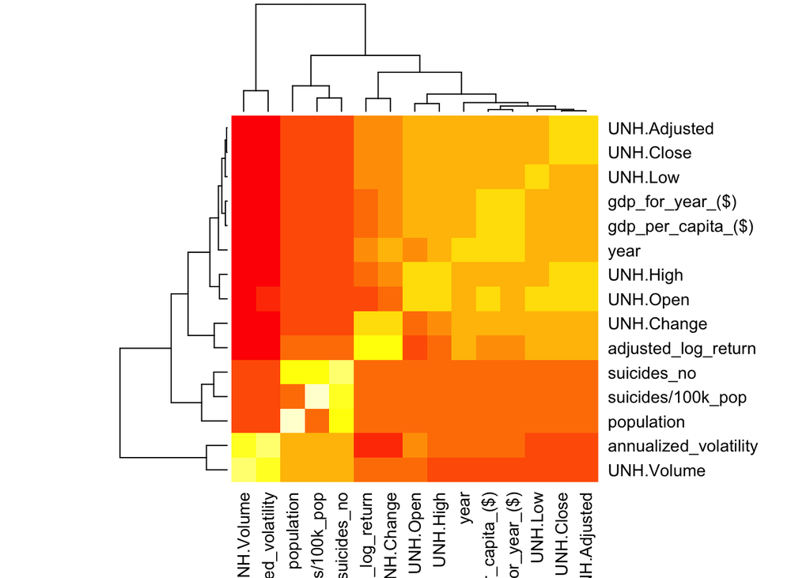

```r
heatmap(cor_matrix)
```

- Create two effective, polished plots with ggplot
  - Each plot should map 3+ variables to aesthetics
  - Each plot should have a title and clean labeling for all mappings
  - Change at least one default theme element and color for at least one mapping per plot
  - For at least one plot, add more tick marks (x, y, or both) than are given by default
  - For at least one plot, use the stat=“summary” function
  - Supporting paragraph or two (for each plot) describing the relationships/trends that are apparent

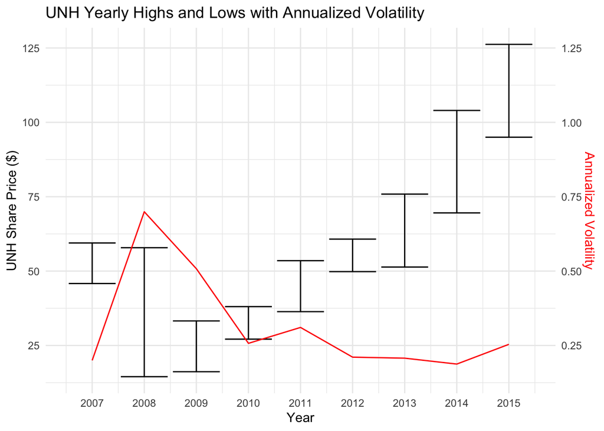

```r
full_data2 = full_data %>%
  select(year, UNH.High, UNH.Low, annualized_volatility) %>%
  unique()

coeff = 1e-2
ggplot(data = full_data2,
       aes(x = year)) +
  geom_errorbar(aes(ymin = UNH.Low,
                    ymax = UNH.High)) +
  geom_line(aes(y = annualized_volatility/coeff), color = "red") +
  # https://www.r-graph-gallery.com/line-chart-dual-Y-axis-ggplot2.html
  scale_y_continuous(
    name = "UNH Share Price ($)",
    # Add a second axis and specify its features
    sec.axis = sec_axis(~.*coeff, name="Annualized Volatility")
  ) +
  labs(title = "UNH Yearly Highs and Lows with Annualized Volatility",
       x = "Year",
       y = "UNH Share Price ($)") +
  scale_x_continuous(breaks = 2007:2015) +
  theme_minimal() +
  theme(axis.title.y.right = element_text(color = "red"))
```

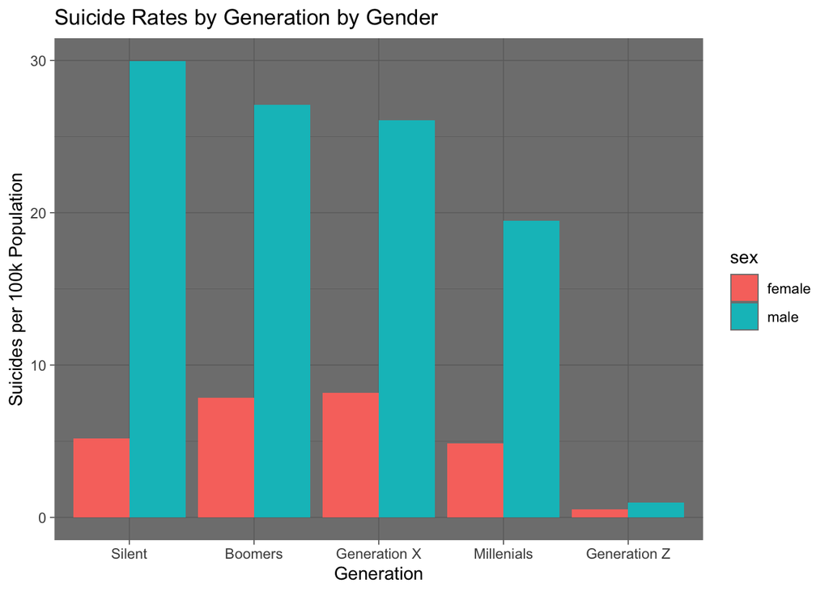

```r
full_data3 = full_data %>%
  group_by(generation, sex) %>%
  summarize(suicides_per_100k_pop = sum(suicides_no)/sum(population)*1e5, .groups = "keep") %>%
  arrange(across(c(sex, suicides_per_100k_pop), desc))


full_data3$generation = ordered(full_data3$generation, levels = full_data3[full_data3$sex == "male", "generation", drop = TRUE])

ggplot(data = full_data3,
       aes(x = generation,
           y = suicides_per_100k_pop,
           fill = sex)) +
  geom_col(position = position_dodge()) +
  labs(title = "Suicide Rates by Generation by Gender",
       x = "Generation",
       y = "Suicides per 100k Population") +
  theme_dark()
```

#### 5. Dimensionality Reduction (20 pts)

- Either k-means/PAM clustering or PCA (inclusive “or”) should be performed on at least three numeric variables in your dataset
  - All relevant steps discussed in class
  - A visualization of the clusters or the first few principal components (using ggplot2)
  - Supporting paragraph or two describing results found

#### 6. Neatness!

- Your project should not knit to more than 30 or so pages (probably closer to 10)! You will lose points if you print out your entire dataset(s), have terrible formatting, etc. If you start your project in a fresh .Rmd file, you are advised to paste the set-up code from this document (lines 14-17) at the top of it: this will automatically truncate if you accidentally print out a huge dataset, etc. Imagine this is a polished report you are giving to your PI or boss to summarize your work researching a topic.

### Where do I find data?

OK, brace yourself!

You can choose ANY datasets you want that meet the above criteria for variables and observations. I’m just sitting here but off the top of my head, if you are into amusement parks, you could look at amusement-park variables, including ticket sales per day etc.; then you could join this by date in weather data. If you are interested in Game of Thrones, you could look at how the frequency of mentions of character names (plus other character variables) and the frequency of baby names in the USA…You could even take your old Biostats data and merge in new data (e.g., based on a Google forms timestamp).

You could engage in some “me-search”: You can [request your Spotify data](https://support.spotify.com/ca-en/article/data-rights-and-privacy-settings/) or [download Netflix viewing activity](https://help.netflix.com/en/node/101917), Amazon purchase history, etc. You can use your Google Fit/Fitbit/Apple watch data, etc. These can be combined (e.g., with each other, with other data sources).

You can make it as serious as you want, or not, but keep in mind that you will be incorporating this project into a portfolio webpage for your final in this course, so choose something that really reflects who you are, or something that you feel will advance you in the direction you hope to move career-wise, or something that you think is really neat. On the flip side, regardless of what you pick, you will be performing all the same tasks, so it doesn’t end up being that big of a deal.

If you are totally clueless and have no direction at all, log into the server and type

```r
data(package = .packages(all.available = TRUE))
```

This will print out a list of **ALL datasets in ALL packages** installed on the server (a ton)! Scroll until your eyes bleed! Actually, do not scroll that much… To start with something more manageable, just run the command on your own computer, or just run `data()` to bring up the datasets in your current environment. To read more about a dataset, do `?packagename::datasetname`.

If it is easier for you, and in case you don’t have many packages installed, a list of R datasets from a few common packages (also downloadable in CSV format) is given at the following website: https://vincentarelbundock.github.io/Rdatasets/datasets.html (including types/numbers of variables in each)

- A good package to download for fun/relevant data is `fivethiryeight`. Just run `install.packages("fivethirtyeight"), load the packages with`library(fivethirtyeight)`, run`data()`, and then scroll down to view the datasets. Here is an online list of all 127 datasets (with links to the 538 articles). Lots of sports, politics, current events, etc: https://cran.r-project.org/web/packages/fivethirtyeight/vignettes/fivethirtyeight.html
- If you have already started to specialize (e.g., ecology, epidemiology) you might look at discipline-specific R packages (vegan, epi, respectively). We will be using some tools from these packages later in the course, but they come with lots of data too, which you can explore according to the directions above
- However, you *emphatically DO NOT* have to use datasets available via R packages! In fact, I would much prefer it if you found the data from completely separate sources and brought them together (a much more realistic experience in the real world)! You can even reuse data from your SDS328M project, provided it shares a variable in common with other data which allows you to merge the two together (e.g., if you still had the timestamp, you could look up the weather that day: https://www.wunderground.com/history/). If you work in a research lab or have access to old data, you could potentially merge it with new data from your lab!
- Here is a curated list of interesting datasets (read-only spreadsheet format): https://docs.google.com/spreadsheets/d/1wZhPLMCHKJvwOkP4juclhjFgqIY8fQFMemwKL2c64vk/edit
- Here is another great compilation of datasets: https://github.com/rfordatascience/tidytuesday
- Here is the UCI Machine Learning Repository: https://archive.ics.uci.edu/ml/index.php
  - See also https://en.wikipedia.org/wiki/List_of_datasets_for_machine-learning_research#Biological_data
- Here is another good general place to look: https://www.kaggle.com/datasets
- To help narrow your search down or to see interesting variable ideas, check out https://www.tylervigen.com/spurious-correlations. This is the spurious correlations website, and it is fun, but if you look at the bottom of each plot you will see sources for the data. This is a good place to find very general data (or at least get a sense of where you can scrape data together from)!
- If you are interested in medical data, check out www.countyhealthrankings.org
- If you are interested in scraping UT data, the university makes *loads* of data public (e.g., beyond just professor CVs and syllabi). Check out all the data that is available in the statistical handbooks: https://reports.utexas.edu/statistical-handbook

##### Broader data sources:

Data.gov 186,000+ datasets!

Social Explorer is a nice interface to Census and American Community Survey data (more user-friendly than the government sites). May need to sign up for a free trial.

U.S. Bureau of Labor Statistics

U.S. Census Bureau

Gapminder, data about the world.

…